# First ARTMO LUT Inversion Simulations

Mattia Rossi

This markdown is used for documenting the ARTMO simulations for LAI retrieval during my period at the IPL, LEO in 2018. I separated the codes by simulation and added the code necessary to plot the results and to document strength and weaknesses of the simulation approach. Each iteration will be calculated in the [R directory](https://github.com/mattia6690/ARTMO_R/tree/master/R) of this repository. The visualization and discussion of the results will be done within the [Documentation directory](https://github.com/mattia6690/ARTMO_R/tree/master/R) sparsed across diverse RMarkdowns

## Setup of Environment

The working environment is setup on the internal server and addressed as follows

```r
ARTMOdir<-"K:/SentinelVegetationProducts/S2_LAI"
ARTMOdir.ss<-paste0(ARTMOdir,"/Subsets")
ARTMOdir.in<-paste0(ARTMOdir,"/ARTMO_Inversion")

source("../R/Essentials.R")
```

```
## Skipping install of 'Mfunctions' from a github remote, the SHA1 (e96b9795) has not changed since last install.
##   Use `force = TRUE` to force installation
```

## First simulation

We used the **ARTMO_inversion_images.R** function to process and store the combination of raster and point data to extract and compare the simulated to the measured LAI values. The results are imported as:

```r
library("tibble")
directory<- "2509_Prosail_Inversion_30000_10Bands_v1"

data<- readRDS(file=paste0(ARTMOdir.in,"/",directory,".rds"))
data<- as.tibble(data)
data
```

```
## # A tibble: 51 x 4
##    Station   Date       Simulated Measured
##    <chr>     <date>         <dbl>    <dbl>
##  1 Domef1500 2017-05-31      2.86     3.69
##  2 Domef1500 2017-05-31      2.86     3.04
##  3 Domef1500 2017-05-31      2.86     4.96
##  4 Domef1500 2017-06-07      2.86     4.84
##  5 Domef1500 2017-06-07      2.86     4.52
##  6 Domef1500 2017-06-07      2.86     3.67
##  7 Domef1500 2017-06-07      2.86     4.62
##  8 Domef1500 2017-06-15      2.93     5.87
##  9 Domef1500 2017-06-15      3.03     5.78
## 10 Domef1500 2017-06-15      3.03     4.38
## # ... with 41 more rows
```

And now the Plots of the Simulated vs the Measured LAI retrieved by this simulation:

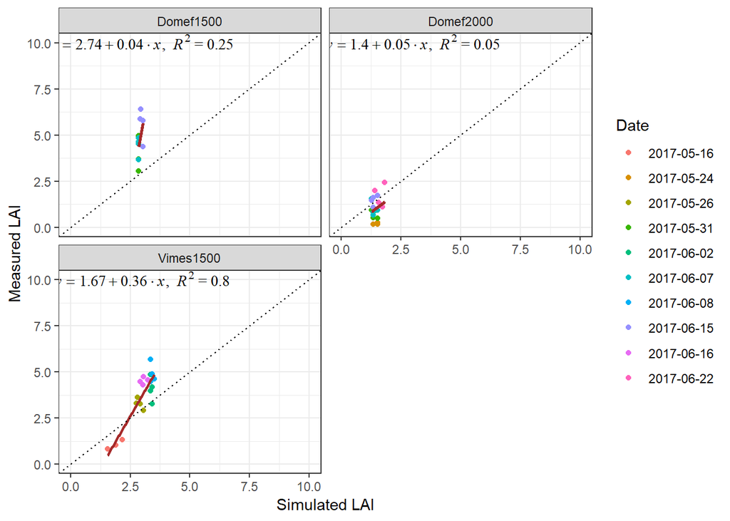

```r
eq1<-data %>%
  group_by(Station) %>% nest %>%
  mutate(Lm=map(data,function(l) lm(l$Simulated~l$Measured))) %>%
  mutate(Eq=map_chr(Lm,r2.equation)) %>%
  dplyr::select(Station,Eq)

g1<-ggplot(data,aes(Simulated,Measured,color=as.character(Date)))+ theme_bw()+
  geom_point()+
  geom_smooth(method="lm",se=F,col="brown")+
  geom_abline(intercept=0,slope=1,linetype="dotted")+
  scale_color_discrete(name = "Date")+
  facet_wrap(.~Station,ncol=2)+
  xlab("Simulated LAI")+ylab("Measured LAI")+
  ylim(c(0,10))+
  xlim(c(0,10))

g1<-g1+geom_text(data=eq1,aes(x=3,y=10,label=Eq,family="serif"),color="black",parse=T)

g1
```